# EDA

```python
import pandas as pd
import numpy as np
import seaborn as sns
import matplotlib.pyplot as plt
from datetime import datetime
import matplotlib.dates as mdates
import missingno as msno

from helper_functions import (plot_patient_stages, ensure_combinations_in_sample,
    get_diagnosis_groups, calculate_bins, plot_kde_only, filter_data_by_time_points,
    count_diagnoses_by_time_point, determine_grid_size, plot_diagnosis_counts,
    map_diagnoses )

pd.set_option('display.max_columns', 200)
```

## Load Data

```python
df = pd.read_csv('tadpole_challenge 3/ADNIMERGE.csv')
```

## Cleaning

```python
df['EXAMDATE'] = pd.to_datetime(df['EXAMDATE'])
df['EXAMDATE_bl'] = pd.to_datetime(df['EXAMDATE_bl'])
df['update_stamp'] = pd.to_datetime(df['update_stamp'])

df = df.sort_values(by=['RID', 'EXAMDATE'])

df['assumedDX'] = df.groupby('RID')['DX'].ffill()

dx_mapping = {'SMC': 'CN', 'LMCI': 'MCI', 'EMCI': 'MCI', 'AD': 'Dementia'}
dx_order = ['CN', 'MCI', 'Dementia']
df = map_diagnoses(df, dx_mapping)
```

# EDA

## Summary Statistics

```python
print("Data Summary:")
df.describe(include='all')
```

```
Data Summary:
```

|  | RID | PTID | VISCODE | SITE | COLPROT | ORIGPROT | EXAMDATE | DX_bl | AGE | PTGENDER | PTEDUCAT | PTETHCAT | PTRACCAT | PTMARRY | APOE4 | FDG | PIB | AV45 | ABETA | TAU | PTAU | CDRSB | ADAS11 | ADAS13 | ADASQ4 | MMSE | RAVLT_immediate | RAVLT_learning | RAVLT_forgetting | … |
| --- | --- | --- | --- | --- | --- | --- | --- | --- | --- | --- | --- | --- | --- | --- | --- | --- | --- | --- | --- | --- | --- | --- | --- | --- | --- | --- | --- | --- | --- | --- |
| count | 13915.000000 | 13915 | 13915 | 13915.000000 | 13915 | 13915 | 13915 | 13892 | 13913.000000 | 13915 | 13915.000000 | 13915 | 13915 | 13915 | 13809.000000 | 3509.000000 | 223.000000 | 2563.000000 | 2370 | 2370 | 2369 | 9984.000000 | 9861.000000 | 9768.000000 | 9885.000000 | 9903.000000 | 9777.000000 | 9777.000000 | 9751.000000 | … |
| unique | NaN | 2155 | 26 | NaN | 4 | 4 | NaN | 5 | NaN | 2 | NaN | 3 | 7 | 5 | NaN | NaN | NaN | NaN | 1818 | 2026 | 2004 | NaN | NaN | NaN | NaN | NaN | NaN | NaN | NaN | … |
| top | NaN | 127_S_0259 | bl | NaN | ADNI2 | ADNI1 | NaN | LMCI | NaN | Male | NaN | Not Hisp/Latino | White | Married | NaN | NaN | NaN | NaN | >1700 | <80 | <8 | NaN | NaN | NaN | NaN | NaN | NaN | NaN | NaN | … |
| freq | NaN | 21 | 2155 | NaN | 6944 | 7091 | NaN | 4863 | NaN | 7774 | NaN | 13457 | 12951 | 10646 | NaN | NaN | NaN | NaN | 351 | 8 | 11 | NaN | NaN | NaN | NaN | NaN | NaN | NaN | NaN | … |
| mean | 2444.460079 | NaN | NaN | 75.541574 | NaN | NaN | 2011-11-09 21:47:13.690262272 | NaN | 73.632624 | NaN | 16.031836 | NaN | NaN | NaN | 0.528423 | 1.206679 | 1.783161 | 1.190413 | NaN | NaN | NaN | 2.100411 | 11.448001 | 17.497446 | 5.138998 | 26.699182 | 35.077222 | 4.117725 | 4.190647 | … |
| min | 2.000000 | NaN | NaN | 2.000000 | NaN | NaN | 2005-09-07 00:00:00 | NaN | 54.400000 | NaN | 4.000000 | NaN | NaN | NaN | 0.000000 | 0.636743 | 1.095000 | 0.805364 | NaN | NaN | NaN | 0.000000 | 0.000000 | 0.000000 | 0.000000 | 0.000000 | 0.000000 | -8.000000 | -33.000000 | … |
| 25% | 667.000000 | NaN | NaN | 21.000000 | NaN | NaN | 2008-10-16 00:00:00 | NaN | 69.300000 | NaN | 14.000000 | NaN | NaN | NaN | 0.000000 | 1.109250 | 1.361250 | 1.008120 | NaN | NaN | NaN | 0.000000 | 6.000000 | 9.000000 | 3.000000 | 25.000000 | 25.000000 | 2.000000 | 3.000000 | … |
| 50% | 1407.000000 | NaN | NaN | 41.000000 | NaN | NaN | 2012-04-10 00:00:00 | NaN | 73.600000 | NaN | 16.000000 | NaN | NaN | NaN | 0.000000 | 1.219400 | 1.850000 | 1.108620 | NaN | NaN | NaN | 1.000000 | 9.000000 | 15.000000 | 5.000000 | 28.000000 | 34.000000 | 4.000000 | 4.000000 | … |
| 75% | 4426.000000 | NaN | NaN | 116.000000 | NaN | NaN | 2013-11-20 12:00:00 | NaN | 78.500000 | NaN | 18.000000 | NaN | NaN | NaN | 1.000000 | 1.312180 | 2.127500 | 1.356305 | NaN | NaN | NaN | 3.000000 | 15.000000 | 23.330000 | 8.000000 | 29.000000 | 44.000000 | 6.000000 | 6.000000 | … |
| max | 6703.000000 | NaN | NaN | 941.000000 | NaN | NaN | 2019-04-09 00:00:00 | NaN | 91.400000 | NaN | 20.000000 | NaN | NaN | NaN | 2.000000 | 1.751210 | 2.927500 | 2.669210 | NaN | NaN | NaN | 18.000000 | 70.000000 | 85.000000 | 10.000000 | 30.000000 | 75.000000 | 14.000000 | 15.000000 | … |
| std | 1979.341686 | NaN | NaN | 115.944372 | NaN | NaN | NaN | NaN | 6.986840 | NaN | 2.807576 | NaN | NaN | NaN | 0.652847 | 0.159207 | 0.422511 | 0.227396 | NaN | NaN | NaN | 2.840762 | 8.431764 | 11.460063 | 3.111431 | 3.925391 | 13.721171 | 2.829069 | 2.613311 | … |

```python
date_range = df['EXAMDATE'].agg(['min', 'max'])
print(f"Date range: {date_range['min']} to {date_range['max']}")
```

```
Date range: 2005-09-07 00:00:00 to 2019-04-09 00:00:00
```

## Missing Data

Identifying and addressing missing data is crucial in healthcare due to its significant impact on data accuracy and analysis. Missing data can lead to biased results, which in turn affects patient care and research outcomes. By pinpointing where data is missing, we can prioritize which variables to address and select appropriate methods for data imputation or exclusion.

There are three main types of missing data: **Missing Completely at Random (MCAR)**, where missingness is unrelated to any data; **Missing at Random (MAR)**, where missingness is related to observed variables but not the missing data itself; and **Missing Not at Random (MNAR)**, where missingness is related to the value of the missing data. Each type requires different handling strategies to minimize bias and ensure the reliability of analyses and decisions.

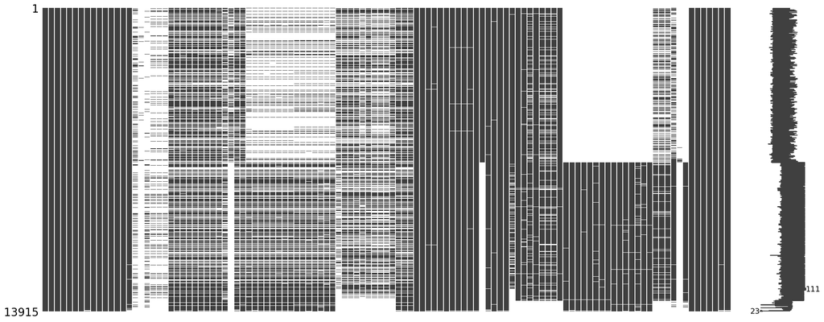

```python
# Visualize missing data matrix
msno.matrix(df)
plt.show()
```

It is obvious from the plot above that some attirubtues become available at diffferent time through the dataset, so we have a look at missingness for each study (ADNI1 / ADNI2 / ADNI3 / ADNIGO)

```python
missing_percentage_by_group = df.groupby('COLPROT').apply(lambda x: x.isnull().mean() * 100)
missing_percentage_by_group
```

| COLPROT | RID | PTID | VISCODE | SITE | COLPROT | ORIGPROT | EXAMDATE | DX_bl | AGE | PTGENDER | PTEDUCAT | PTETHCAT | PTRACCAT | PTMARRY | APOE4 | FDG | PIB | AV45 | ABETA | TAU | PTAU | CDRSB | ADAS11 | ADAS13 | ADASQ4 | MMSE | RAVLT_immediate | RAVLT_learning | RAVLT_forgetting | … |
| --- | --- | --- | --- | --- | --- | --- | --- | --- | --- | --- | --- | --- | --- | --- | --- | --- | --- | --- | --- | --- | --- | --- | --- | --- | --- | --- | --- | --- | --- | --- |
| ADNI1 | 0.0 | 0.0 | 0.0 | 0.0 | 0.0 | 0.0 | 0.0 | 0.000000 | 0.00000 | 0.0 | 0.0 | 0.0 | 0.0 | 0.0 | 0.000000 | 65.330142 | 95.551566 | 100.000000 | 81.667664 | 81.667664 | 81.667664 | 23.738280 | 23.319370 | 24.396569 | 23.279473 | 23.079992 | 23.857969 | 23.857969 | 24.117295 | … |
| ADNI2 | 0.0 | 0.0 | 0.0 | 0.0 | 0.0 | 0.0 | 0.0 | 0.000000 | 0.00000 | 0.0 | 0.0 | 0.0 | 0.0 | 0.0 | 0.158410 | 80.702765 | 100.000000 | 72.695853 | 81.581221 | 81.581221 | 81.595622 | 32.474078 | 33.755760 | 34.216590 | 33.597350 | 33.597350 | 34.432604 | 34.432604 | 34.576613 | … |
| ADNI3 | 0.0 | 0.0 | 0.0 | 0.0 | 0.0 | 0.0 | 0.0 | 1.993068 | 0.17331 | 0.0 | 0.0 | 0.0 | 0.0 | 0.0 | 7.972270 | 86.481802 | 100.000000 | 64.818024 | 100.000000 | 100.000000 | 100.000000 | 13.431542 | 18.284229 | 18.717504 | 17.504333 | 16.551127 | 18.890815 | 18.890815 | 18.890815 | … |
| ADNIGO | 0.0 | 0.0 | 0.0 | 0.0 | 0.0 | 0.0 | 0.0 | 0.000000 | 0.00000 | 0.0 | 0.0 | 0.0 | 0.0 | 0.0 | 0.373134 | 65.796020 | 100.000000 | 67.537313 | 78.606965 | 78.606965 | 78.606965 | 41.169154 | 41.044776 | 41.293532 | 40.796020 | 41.169154 | 41.417910 | 41.417910 | 41.791045 | … |

In the table we see the following columns are 100% missing for certain studies:

- **PIB** - Majority missing in all groups
- **AV45 / AV45_bl** - Missing in ADNI1
- **ABETA, TAU, PTAU** - Missing in ADNI3
- **DIGITSCOR** - Missing in ADNI2, ADNI3, ADNIGO
- **MOCA / MOCA_bl** - Missing in ADNI1
- **EcogPtMem / EcogPtMem_bl** - Missing in ADNI1
- **EcogPtLang / EcogPtLang_bl** - Missing in ADNI1
- **EcogPtVisspat / EcogPtVisspat_bl** - Missing in ADNI1
- **EcogPtPlan / EcogPtPlan_bl** - Missing in ADNI1
- **EcogPtOrgan / EcogPtOrgan_bl** - Missing in ADNI1
- **EcogPtDivatt / EcogPtDivatt_bl** - Missing in ADNI1
- **EcogPtTotal /EcogPtTotal _bl** - Missing in ADNI1
- **EcogSPMem / EcogSPMem_bl** - Missing in ADNI1
- **EcogSPLang / EcogSPLang_bl** - Missing in ADNI1
- **EcogSPVisspat / EcogSPVisspat_bl** - Missing in ADNI1
- **EcogSPPlan / EcogSPPlan_bl** - Missing in ADNI1
- **EcogSPOrgan / EcogSPOrgan_bl** - Missing in ADNI1
- **EcogSPDivatt / EcogSPDivatt_bl** - Missing in ADNI1
- **EcogSPTotal / EcogSPTotal_bl** - Missing in ADNI1
- **FLDSTRENG** - Missing in ADNI3
- **FSVERSION** - Missing in ADNI3
- **IMAGEUID** - Missing in ADNI3
- **Ventricles** - Missing in ADNI3
- **Hippocampus** - Missing in ADNI3
- **WholeBrain** - Missing in ADNI3
- **Entorhinal** - Missing in ADNI3
- **Fusiform** - Missing in ADNI3
- **MidTemp** - Missing in ADNI3
- **ICV** - Missing in ADNI3

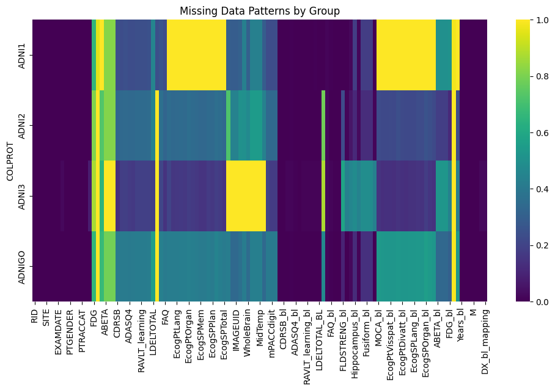

```python
# Missing data by group
plt.figure(figsize=(12, 6))
missing_data_patterns = df.groupby('COLPROT').apply(lambda x: x.isnull().mean())
sns.heatmap(missing_data_patterns, annot=False, cmap='viridis')
plt.title('Missing Data Patterns by Group')
plt.show()
```

## Distribution of Distinct Visits per Patient

In this section, we analyze the distribution of distinct visits per patient. We start by calculating the number of unique visits each patient has had, using the VISCODE column. The code groups the data by patient ID (RID) and counts the number of distinct visit codes.

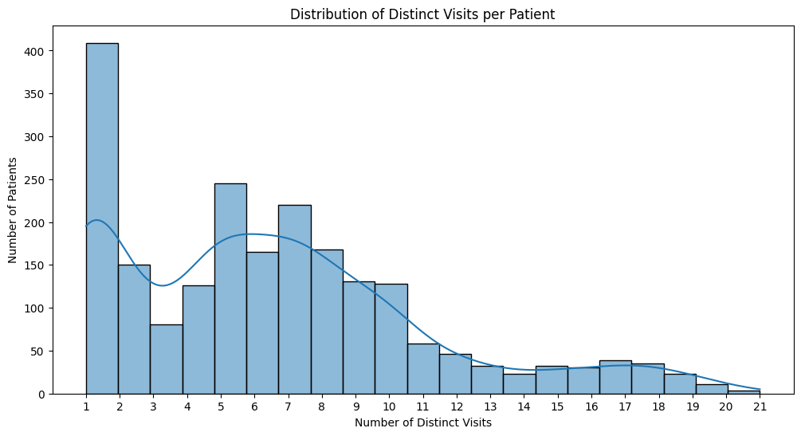

```python
distinct_visits_per_patient = df.groupby('RID')['VISCODE'].nunique()

distinct_visits_per_patient_df = distinct_visits_per_patient.reset_index()
distinct_visits_per_patient_df.columns = ['RID', 'Distinct_Visit_Count']

plt.figure(figsize=(12, 6))
sns.histplot(distinct_visits_per_patient_df['Distinct_Visit_Count'], kde=True, bins=len(distinct_visits_per_patient_df['Distinct_Visit_Count'].unique()))
plt.title('Distribution of Distinct Visits per Patient')
plt.xlabel('Number of Distinct Visits')
plt.ylabel('Number of Patients')
max_visits = distinct_visits_per_patient_df['Distinct_Visit_Count'].max()
min_visits = distinct_visits_per_patient_df['Distinct_Visit_Count'].min()
plt.xticks(range(min_visits, max_visits + 1, 1))

plt.show()
```

The histogram reveals that a significant number of patients have only a single visit recorded. Additionally, there is a notable secondary peak in the distribution between 5 and 7 visits. The analysis also identifies that the maximum number of visits recorded for a patient is 21. This distribution helps us understand the variability in patient visit frequency and can inform further analysis on patient engagement and data completeness.

For subsequent analyses focused on Alzheimer's progression, it will be important to exclude patients who have only a single visit. This step will ensure that the analysis is based on patients with more extensive visit records, providing a more robust basis for studying the progression of Alzheimer's disease.

```python
single_entry_ids = distinct_visits_per_patient_df[distinct_visits_per_patient_df['Distinct_Visit_Count'] == 1]['RID'].tolist()
df = df[~df['RID'].isin(single_entry_ids)]
```

## Progression of Alzheimer's disease

The plot_patient_stages function visualizes the progression of Alzheimer's disease across multiple patients by displaying each patient’s timeline through a horizontal bar chart. This analysis is instrumental for understanding the variability in disease progression among patients.

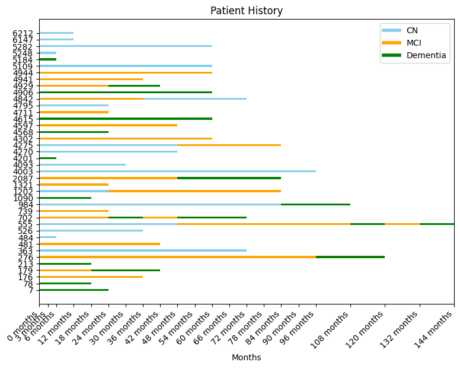

```python
num_samples = 40
sampled_df = ensure_combinations_in_sample(df, patient_col='RID', dx_col='assumedDX', num_samples=num_samples)

plot_patient_stages(sampled_df)
```

Disease Progression: The chart reveals how patients transition between stages over time. For example, some patients start in a normal cognitive state and transition to MCI or Dementia, while others might already be in the Dementia stage from the beginning or progress more rapidly.

Patient Variability: The visualization highlights the diversity in disease trajectories among patients. This includes:

- Progressive Cases: Patients who show a clear progression from CN to MCI and then to Dementia.
- Stable Cases: Patients who remain in a single stage, such as MCI, throughout the timeline.
- Advanced Cases: Patients who might start in Dementia or quickly advance to that stage.

(I select a random sample of patients as I aim to achieve a balance between data comprehensiveness and practical constraints, ensuring that the visualization remains clear, informative, and manageable. This approach helps in making the data analysis process more efficient while still providing a representative view of the patient population.)

## Analysis of Diagnosis Over Time

We aim to understand the distribution and progression of diagnoses across different time points in our study. The plot_diagnosis_counts function provides a series of bar charts that depict the counts of different diagnoses (e.g., CN, MCI, Dementia) at each time point.

The bar charts provide a valuable visual representation of diagnosis counts over time, highlighting both the progression of cognitive conditions and the impact of participant dropout. Understanding these trends helps in interpreting the data accurately and addressing potential biases introduced by missing data.

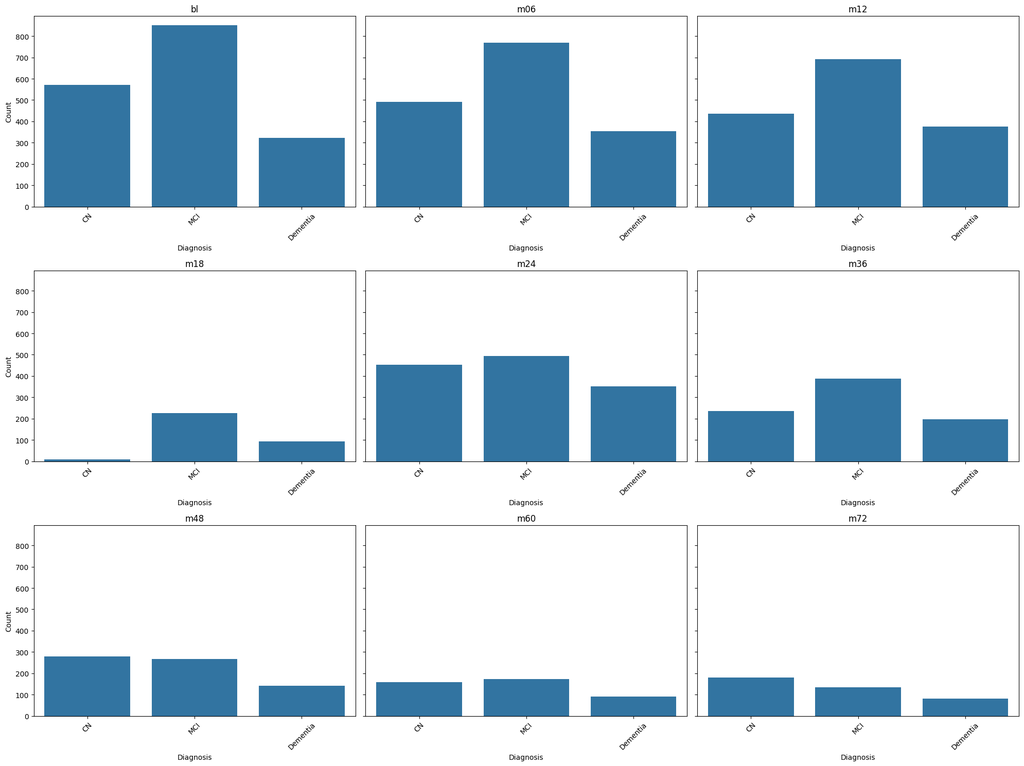

```python
time_points = ['bl', 'm06', 'm12', 'm18', 'm24', 'm36', 'm48', 'm60', 'm72']
dx_order = ['CN', 'MCI', 'Dementia']

# Assuming df is your DataFrame
filtered_data = filter_data_by_time_points(df, time_points)
diagnosis_counts = count_diagnoses_by_time_point(filtered_data, dx_order)
grid_size = determine_grid_size(len(time_points))
plot_diagnosis_counts(diagnosis_counts, grid_size, dx_order)
```

## Patient Demographics

Analyzing demographic data such as age, gender, marital status, education, race, and ethnicity provides insights into the patient population's characteristics, which can impact disease progression and treatment outcomes.

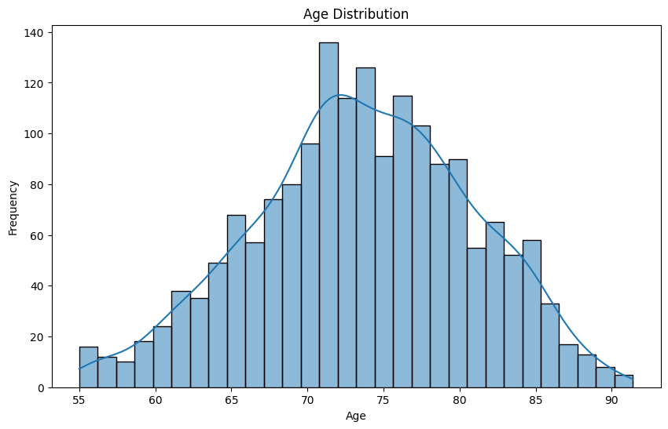

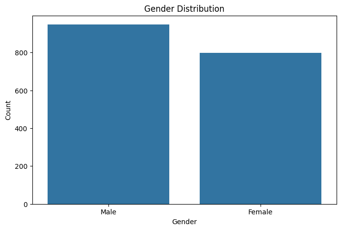

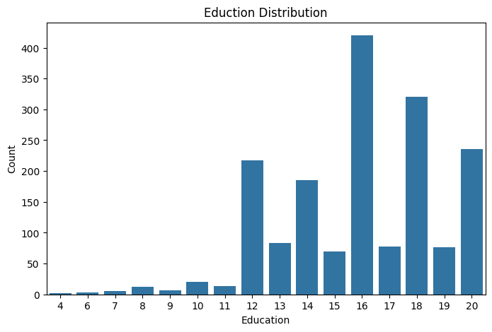

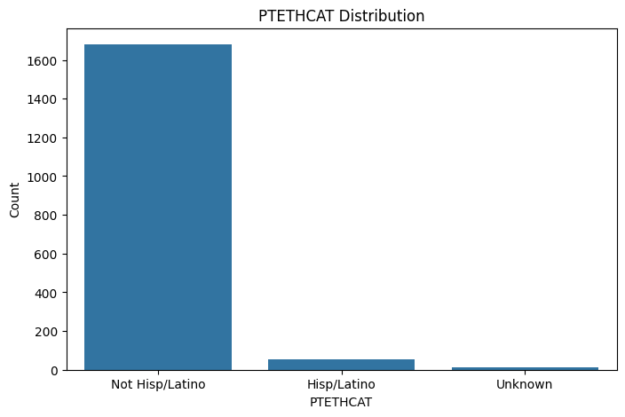

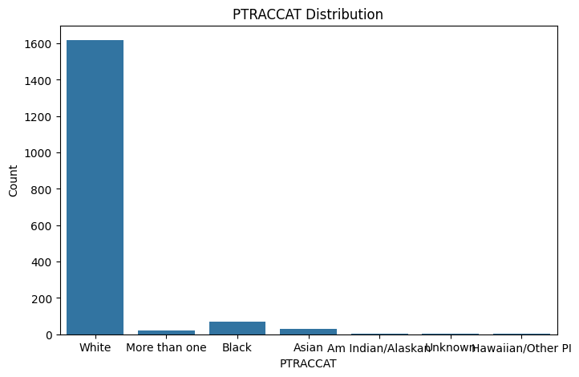

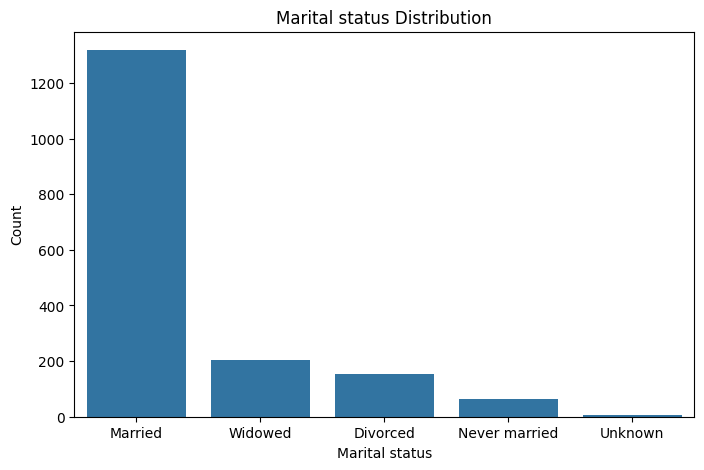

```python
demographics_df = df[df['VISCODE']=='bl']
# Age Distribution
plt.figure(figsize=(10, 6))
sns.histplot(demographics_df['AGE'], kde=True, bins=30)
plt.title('Age Distribution')
plt.xlabel('Age')
plt.ylabel('Frequency')
plt.show()

# Gender Distribution
plt.figure(figsize=(8, 5))
sns.countplot(x='PTGENDER', data=demographics_df)
plt.title('Gender Distribution')
plt.xlabel('Gender')
plt.ylabel('Count')
plt.show()

# Education Distribution
plt.figure(figsize=(8, 5))
sns.countplot(x='PTEDUCAT', data=demographics_df)
plt.title('Eduction Distribution')
plt.xlabel('Education')
plt.ylabel('Count')
plt.show()

# PTETHCAT Distribution
plt.figure(figsize=(8, 5))
sns.countplot(x='PTETHCAT', data=demographics_df)
plt.title('PTETHCAT Distribution')
plt.xlabel('PTETHCAT')
plt.ylabel('Count')
plt.show()

# PTRACCAT Distribution
plt.figure(figsize=(8, 5))
sns.countplot(x='PTRACCAT', data=demographics_df)
plt.title('PTRACCAT Distribution')
plt.xlabel('PTRACCAT')
plt.ylabel('Count')
plt.show()

# Marital status Distribution
plt.figure(figsize=(8, 5))
sns.countplot(x='PTMARRY', data=demographics_df)
plt.title('Marital status Distribution')
plt.xlabel('Marital status')
plt.ylabel('Count')
plt.show()
```

- Age: The age distribution is between 55 and 90 years, with a peak between 70 and 75 years.
- Gender: There are slightly more men in the dataset.
- Marital Status: The majority of patients are married, followed by widowed and divorced.
- Education Level: The majority of patients have 16 years of education, with significant numbers also having 18, 20, 12, and 14 years.
- Race: The majority of the patients are White.
- Ethnicity: The majority of the patients are not Hispanic or Latino.

## Biomarkers

In this analysis, we investigate how various biomarkers change over time. By examining the differences between baseline and final appointment measurements for several biomarkers, we can gain insights into how these changes are associated with the progression of alzhiemers.

By examining the KDE plots, we can identify how changes in biomarkers differ between those with no change in diagnosis and those who progress through different diagnostic stages (e.g., CN to MCI, MCI to AD).

For example, we observe changes in biomarkers RAVLT in groups progressing to Dementia compared to those with no change or those transitioning from CN to MCI.

```python
df.loc[:, 'CDRSB_delta'] = df.CDRSB - df.CDRSB_bl
df.loc[:, 'ADAS11_delta'] = df.ADAS11 - df.ADAS11_bl
df.loc[:, 'ADAS13_delta'] = df.ADAS13 - df.ADAS13_bl
df.loc[:, 'MMSE_delta'] = df.MMSE - df.MMSE_bl
df.loc[:, 'RAVLT_delta'] = df.RAVLT_immediate - df.RAVLT_immediate_bl
df.loc[:, 'Hippocampus_delta'] = df.Hippocampus - df.Hippocampus_bl
df.loc[:, 'Ventricles_delta'] = df.Ventricles - df.Ventricles_bl
df.loc[:, 'WholeBrain_delta'] = df.WholeBrain - df.WholeBrain_bl
df.loc[:, 'Entorhinal_delta'] = df.Entorhinal - df.Entorhinal_bl
df.loc[:, 'MidTemp_delta'] = df.MidTemp - df.MidTemp_bl
```

```python
labels = ('No Change', 'CN to MCI', 'MCI to AD', 'CN to AD')
biomarkers = df.filter(like='_delta').columns
last_dx_records = df.groupby('RID').last().reset_index()
```

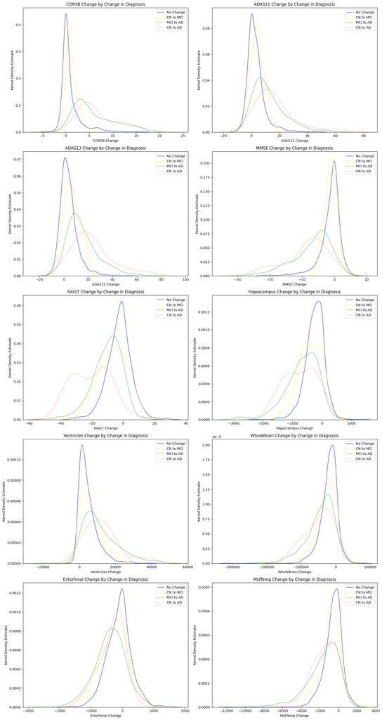

```python
# Get diagnosis groups
dist_groups = get_diagnosis_groups(last_dx_records)
plot_kde_only(biomarkers, dist_groups, labels)
```